# Caching + Sharding + Consistent Hashing + Data Structures for Big Data

Combined system design interview notebook.

Topics included:

1. Caching
2. Sharding
3. Consistent Hashing
4. Data Structures for Big Data
   - Bloom Filter
   - Count-Min Sketch
   - HyperLogLog
   - Approximate Quantiles / Bucket Algorithms

Each section has:

- Simple explanation
- When to use
- When not to use
- Common pitfalls
- Interview answer

# Index

## Part 1 — Caching

1. What is Caching?
2. Why Use Caching?
3. Where to Cache?
4. External Cache: Redis / Memcached
5. CDN Cache
6. Client-Side Cache
7. In-Process Cache
8. Cache-Aside / Lazy Loading
9. Write-Through Cache
10. Write-Behind / Write-Back Cache
11. Read-Through Cache
12. Cache Eviction Policies
13. Cache Stampede / Thundering Herd
14. Cache Consistency
15. Hot Keys in Cache
16. Cache Failure Handling
17. Caching Interview Answer

## Part 2 — Sharding

18. What is Sharding?
19. Partitioning vs Sharding
20. Shard Key
21. Good vs Bad Shard Key
22. Range-Based Sharding
23. Hash-Based Sharding
24. Directory-Based Sharding
25. Hot Spots in Sharding
26. Cross-Shard Queries
27. Cross-Shard Transactions
28. Modern Databases and Sharding
29. Sharding Interview Answer

## Part 3 — Consistent Hashing

30. What Problem Does Consistent Hashing Solve?
31. Simple Modulo Hashing
32. Problem with Modulo Hashing
33. Consistent Hashing / Hash Ring
34. Adding and Removing Nodes
35. Virtual Nodes
36. Consistent Hashing vs Hot Spots
37. Real-World Usage
38. Consistent Hashing Interview Answer

## Part 4 — Data Structures for Big Data

39. Why Specialized Data Structures?
40. Bloom Filter
41. Bloom Filter: How It Works
42. Bloom Filter: Use Cases and Pitfalls
43. Count-Min Sketch
44. Count-Min Sketch: How It Works
45. Count-Min Sketch: Use Cases and Pitfalls
46. HyperLogLog
47. HyperLogLog: How It Works
48. HyperLogLog: Use Cases and Pitfalls
49. Approximate Quantiles / Bucket Algorithms
50. Bucket Algorithm Variants
51. Approximate Quantiles: Use Cases and Pitfalls
52. Big Data Structures Decision Table
53. Final Combined Interview Answer

## Extra Code

54. Cache-Aside Pseudocode
55. Hash-Based Shard Routing Pseudocode
56. Consistent Hash Ring Pseudocode
57. Simple Bloom Filter Example

# 1. What is Caching?

**Caching** means storing frequently accessed data in fast storage, usually memory, so the system does not repeatedly hit the database.

```
Application
   ↓
Cache
   ↓ cache miss
Database
```

Main goal:

```
Reduce database load
Improve latency
Serve repeated reads faster
```

Caching is mostly used for read-heavy systems.

⬆ Back to Index

# 2. Why Use Caching?

Database reads may take tens of milliseconds.

Cache reads may take around one millisecond or less.

Example:

```
Postgres read → ~50 ms
Redis read    → ~1 ms
```

Caching helps when:

- Database CPU is high
- Same data is read repeatedly
- Query is expensive
- Low latency is required
- Read traffic is much higher than write traffic

Tradeoff:

```
Faster reads
But stale data and invalidation become harder
```

⬆ Back to Index

# 3. Where to Cache?

| Cache Layer | Example | Best For |
| --- | --- | --- |
| External cache | Redis, Memcached | App/database read scaling |
| CDN cache | CloudFront, Cloudflare, Fastly | Static/public content |
| Client-side cache | Browser/mobile cache | Offline/repeated client reads |
| In-process cache | App memory | Small hot values/config |

Interview default:

```
Start with Redis/Memcached external cache.
Mention CDN for static media.
Mention in-process cache only as optimization.
```

⬆ Back to Index

# 4. External Cache: Redis / Memcached

External cache is the most common system design answer.

Architecture:

```
Application
   ↓
Redis / Memcached
   ↓ cache miss
Database
```

Use for:

- User profiles
- Product details
- Trending feeds
- Session data
- Video metadata
- Frequently read objects

Pros:

- Shared by all app servers
- Very fast
- Reduces DB load
- Supports TTL and eviction

Cons:

- Network call required
- Cache can fail
- Data can become stale

⬆ Back to Index

# 5. CDN Cache

A CDN caches content close to users globally.

```
User
 ↓
Nearest CDN Edge
 ↓ cache miss
Origin Server / Blob Storage
```

Best for:

- Images
- Videos
- Static files
- Public pages
- Thumbnails
- Media delivery

Use CDN when:

- Content is public or shareable
- Users are global
- Static/media content is served at scale

⬆ Back to Index

# 6. Client-Side Cache

Client-side cache stores data on the user's device.

Examples:

- Browser HTTP cache
- localStorage
- Mobile app local cache
- Offline app storage

Use for:

- Offline access
- Previously loaded content
- Images/static assets
- App state

Problem:

```
Backend has less control
Invalidation is hard
Data may become stale
```

⬆ Back to Index

# 7. In-Process Cache

In-process cache stores data inside application server memory.

Good for:

- Feature flags
- Config values
- Small reference data
- Extremely hot keys
- Rate limiting counters
- Small precomputed values

Pros:

```
Fastest cache
No network call
```

Cons:

```
Not shared across servers
Hard invalidation
Limited memory
```

⬆ Back to Index

# 8. Cache-Aside / Lazy Loading

Most common caching pattern.

```
1. App checks cache
2. Cache hit → return data
3. Cache miss → query DB
4. Store result in cache
5. Return data
```

Use by default in interviews.

Pros:

- Simple
- Cache only stores data actually used
- Works well with Redis/Memcached

Cons:

- First request after miss is slower
- Need invalidation strategy

⬆ Back to Index

# 9. Write-Through Cache

Application writes to cache.

Cache synchronously writes to database.

```
App
 ↓ write
Cache
 ↓ write
Database
```

Pros:

- Reads are fresh
- Cache and DB updated together

Cons:

- Slower writes
- Cache pollution
- Dual-write failure risk

Use when:

```
Reads must return fresh data
Writes can be slightly slower
```

⬆ Back to Index

# 10. Write-Behind / Write-Back Cache

Application writes to cache first.

Cache writes to database asynchronously later.

```
App
 ↓ write
Cache
 ↓ async flush
Database
```

Pros:

- Very fast writes
- High throughput

Cons:

- Data loss possible if cache crashes before flush
- Eventual consistency

Use for:

- Metrics
- Analytics
- Logs
- High-volume non-critical writes

⬆ Back to Index

# 11. Read-Through Cache

Cache fetches from DB on miss.

```
App
 ↓
Cache
 ↓ cache miss
Database
```

Common in:

- CDN caching
- Specialized cache libraries

Interview note:

```
Use cache-aside for Redis.
Use read-through when discussing CDN/proxy-like cache.
```

⬆ Back to Index

# 12. Cache Eviction Policies

| Policy | Meaning | Use Case |
| --- | --- | --- |
| LRU | Remove least recently used | Good default |
| LFU | Remove least frequently used | Consistently popular items |
| FIFO | Remove oldest inserted item | Simple systems |
| TTL | Expire after time | Freshness control |

Important:

```
TTL is usually combined with LRU/LFU.
```

Example:

```
User profile TTL = 10 minutes
Trending feed TTL = 60 seconds
```

⬆ Back to Index

# 13. Cache Stampede / Thundering Herd

Problem:

```
Popular cache key expires
↓
Thousands of requests miss together
↓
All hit DB
↓
DB overload
```

Solutions:

- Request coalescing / single flight
- Cache warming
- Probabilistic early refresh
- Background refresh
- Serve stale while refreshing

Best answer:

```
Only one request rebuilds the cache.
Others wait or get stale cached value.
```

⬆ Back to Index

# 14. Cache Consistency

Problem:

```
Database has new value
Cache still has old value
```

Solutions:

- Invalidate cache on writes
- Use short TTL
- Accept eventual consistency
- Use versioned cache keys
- Read from source of truth when strong consistency is needed

Example:

```
Update DB
Delete cache key
Next read reloads fresh data
```

⬆ Back to Index

# 15. Hot Keys in Cache

Hot key = one cache key gets huge traffic.

Example:

```
user:taylorswift
```

Solutions:

- Replicate hot key
- Use local in-process cache
- Rate limit abusive traffic
- Split/salt hot key if possible

Important:

```
Caching solves repeated DB reads,
but hot keys can still overload the cache layer.
```

⬆ Back to Index

# 16. Cache Failure Handling

Problem:

```
Redis goes down
↓
All requests fall back to DB
↓
DB gets overloaded
```

Solutions:

- Circuit breaker
- Rate limiting
- Fallback to stale data
- Small in-process cache
- Graceful degradation
- Protect DB from stampede

Interview line:

```
If cache fails, I do not want all traffic to crush the database.
```

⬆ Back to Index

# 17. Caching Interview Answer

> I use caching when the system has high read traffic, repeated expensive queries, or strict latency requirements. I usually start with Redis using the cache-aside pattern: the application checks cache first, falls back to the database on a miss, stores the result with a TTL, and returns it. I cache data that is read often and changes infrequently, such as user profiles, product details, video metadata, or trending feeds. For static media, I use a CDN. I also handle cache invalidation on writes, choose an eviction policy like LRU with TTL, and protect against cache stampede, hot keys, and cache failures using request coalescing, cache warming, hot-key replication, circuit breakers, and graceful degradation.

⬆ Back to Index

# 18. What is Sharding?

**Sharding** means splitting data across multiple database machines when one database can no longer handle storage, reads, or writes.

```
Shard 1 → Users 1–1M
Shard 2 → Users 1M–2M
Shard 3 → Users 2M–3M
```

Each shard has its own:

- CPU
- Memory
- Storage
- Connection pool

Goal:

```
No single machine stores all data or handles all traffic.
```

⬆ Back to Index

# 19. Partitioning vs Sharding

| Concept | Meaning |
| --- | --- |
| Partitioning | Split data inside one database |
| Sharding | Split data across multiple databases/machines |

Simple difference:

```
Partitioning = one machine
Sharding = many machines
```

⬆ Back to Index

# 20. Shard Key

Shard key = field used to decide where data lives.

Example:

```
Shard by user_id
Distribute using hash(user_id)
```

Ask:

- Does it have many unique values?
- Does it distribute data evenly?
- Do common queries use this key?
- Will it avoid hot shards?
- Will it keep related data together?

⬆ Back to Index

# 21. Good vs Bad Shard Key

Good shard key properties:

| Property | Meaning |
| --- | --- |
| High cardinality | Many unique values |
| Even distribution | Data spreads evenly |
| Query alignment | Common queries hit one shard |

Good examples:

```
user_id
order_id
post_id
tenant_id
```

Bad examples:

```
is_premium
country
created_at
```

Why bad?

```
is_premium → only true/false
country → some countries overloaded
created_at → latest shard gets all new writes
```

⬆ Back to Index

# 22. Range-Based Sharding

Range sharding groups records by continuous ranges.

```
Shard 1 → user_id 1–1M
Shard 2 → user_id 1M–2M
Shard 3 → user_id 2M–3M
```

Pros:

- Simple
- Good for range queries

Cons:

- Can create hot shards
- New writes may go to latest range

Good for:

- Multi-tenant systems
- Range queries
- Data naturally grouped by ranges

⬆ Back to Index

# 23. Hash-Based Sharding

Hash sharding uses a hash function.

```
shard = hash(user_id) % number_of_shards
```

Pros:

- Even distribution
- Common default strategy
- Good for high-cardinality keys

Cons:

- Adding/removing shards causes data movement
- Range queries are harder

Better version:

```
Consistent hashing
```

⬆ Back to Index

# 24. Directory-Based Sharding

Directory sharding uses a lookup table.

```
User 15  → Shard 1
User 87  → Shard 4
User 204 → Shard 2
```

Pros:

- Very flexible
- Can move hot users to dedicated shards
- Supports custom placement logic

Cons:

- Extra lookup on every request
- Directory service becomes critical dependency
- Adds latency
- More operational complexity

⬆ Back to Index

# 25. Hot Spots in Sharding

Hot spot = one shard receives much more traffic than others.

Example:

```
Taylor Swift profile/post gets 1000x traffic
```

Solutions:

- Move hot key to dedicated shard
- Use compound shard key
- Split hot keys
- Dynamic shard splitting
- Cache popular data

Important:

```
Hashing spreads keys evenly.
It does not guarantee traffic is evenly distributed.
```

⬆ Back to Index

# 26. Cross-Shard Queries

Problem:

```
Query needs data from many shards
```

Example:

```
Top 10 popular posts globally
```

Solutions:

- Cache results
- Precompute using background job
- Denormalize data
- Accept only for rare admin queries

Interview warning:

```
If a common query hits all shards, rethink the shard key or data model.
```

⬆ Back to Index

# 27. Cross-Shard Transactions

Problem:

```
User account on Shard 1
Transaction record on Shard 2
```

Single DB transaction no longer works.

Solutions:

| Approach | When |
| --- | --- |
| Avoid cross-shard transaction | Best option |
| Keep related data together | Shard by user_id/tenant_id |
| Saga pattern | Multi-step eventual consistency |
| 2PC | Strong consistency but slow/fragile |

Best design:

```
Choose shard key so common transactions stay on one shard.
```

⬆ Back to Index

# 28. Modern Databases and Sharding

Many systems handle sharding internally.

| Database | Sharding Behavior |
| --- | --- |
| Cassandra | Partition key + virtual nodes |
| DynamoDB | Partition key + internal partitions |
| MongoDB | Shard key + chunk balancing |
| Vitess | Sharding layer for MySQL |
| Citus | Sharding layer for PostgreSQL |
| Spanner | Distributed SQL with built-in distribution |

Interview examples:

```
Use DynamoDB with user_id as partition key
Use Vitess to shard MySQL by user_id
```

⬆ Back to Index

# 29. Sharding Interview Answer

> Sharding is splitting data across multiple database machines when a single database can no longer handle storage, read throughput, or write throughput. I would first prove sharding is needed through capacity estimates. Then I would choose a shard key with high cardinality, even distribution, and alignment with query patterns, such as `user_id` for user-centric systems. I would usually use hash-based sharding with consistent hashing to distribute data evenly and reduce data movement during resharding. I would also address tradeoffs like hot spots, cross-shard queries, cross-shard transactions, and rebalancing.

⬆ Back to Index

# 30. What Problem Does Consistent Hashing Solve?

Consistent hashing distributes keys across servers while minimizing data movement when servers are added or removed.

Used for:

- Distributed databases
- Distributed caches
- CDNs
- Message brokers
- Sharded systems

Main question:

```
How do we decide which server owns which key?
```

And:

```
How do we avoid moving almost all data when servers change?
```

⬆ Back to Index

# 31. Simple Modulo Hashing

Basic approach:

```
database_id = hash(event_id) % number_of_databases
```

Example with 3 databases:

```
Event 1234 → hash(1234) % 3 → DB1
Event 5678 → hash(5678) % 3 → DB0
Event 9012 → hash(9012) % 3 → DB2
```

This is simple when the number of databases does not change.

⬆ Back to Index

# 32. Problem with Modulo Hashing

If databases change from 3 to 4:

```
hash(event_id) % 3
```

becomes:

```
hash(event_id) % 4
```

Problem:

```
Most keys now map to different databases
```

Result:

- Massive data movement
- High DB load
- Slow responses
- Rebalancing pain

⬆ Back to Index

# 33. Consistent Hashing / Hash Ring

Consistent hashing places both servers and keys on a circular space called a hash ring.

```
0 ───── 25 ───── 50 ───── 75 ───── 100
DB1     DB2      DB3      DB4
```

To place a key:

```
1. Hash the key
2. Find position on ring
3. Move clockwise
4. Store on first server found
```

Benefit:

```
When server count changes, only nearby keys move.
```

⬆ Back to Index

# 34. Adding and Removing Nodes

Adding a node:

```
Only keys in the affected ring range move.
Everything else stays where it is.
```

Removing a node:

```
Only data from the removed node moves.
That data goes to the next clockwise node.
```

Benefit:

```
Failure or scaling event affects only a bounded subset of keys.
```

⬆ Back to Index

# 35. Virtual Nodes

Problem without virtual nodes:

```
If one DB fails, its load may move mostly to one neighbor
```

Solution:

```
Use virtual nodes
```

Instead of placing each database once on the ring, place it multiple times.

```
DB1-v1
DB1-v2
DB1-v3

DB2-v1
DB2-v2
DB2-v3
```

Benefits:

- Better load distribution
- Smoother node addition
- Smoother node removal

⬆ Back to Index

# 36. Consistent Hashing vs Hot Spots

Consistent hashing distributes keys, not traffic.

Problem:

```
Taylor Swift concert gets 100x more traffic
```

Solutions:

| Problem | Solution |
| --- | --- |
| Popular key gets too many reads | Read replicas |
| One key too hot | Key salting |
| Node overloaded | Adaptive rebalancing |

Important distinction:

```
Virtual nodes solve uneven key distribution.
Replication/salting solve uneven traffic distribution.
```

⬆ Back to Index

# 37. Real-World Usage

Used in or related to:

| System | Usage |
| --- | --- |
| Cassandra | Distributes data across ring |
| DynamoDB | Partition placement concepts |
| CDNs | Decide edge/cache placement |
| Distributed caches | Map keys to cache nodes |
| Distributed databases | Sharding/partitioning |

Redis Cluster uses fixed hash slots instead of classic consistent hashing:

```
16,384 slots
```

⬆ Back to Index

# 38. Consistent Hashing Interview Answer

> Consistent hashing is used to distribute keys across servers while minimizing data movement when servers are added or removed. Instead of using `hash(key) % number_of_servers`, we place servers and keys on a hash ring. A key is assigned to the first server clockwise from its hash position. When a server is added or removed, only nearby keys move, not the whole dataset. Virtual nodes improve load balancing, while replication and key salting help handle failures and hot keys.

⬆ Back to Index

# 39. Why Specialized Data Structures?

Some systems process massive datasets where normal exact structures become too expensive.

Examples:

- Trillions of IDs
- Billions of events
- Massive URL crawl sets
- Huge analytics streams
- High-cardinality metrics
- Real-time percentiles

Specialized data structures help when you can accept approximation.

Important warning:

```
Do not over-engineer.
If a normal hash table works, use it.
```

These are useful when:

- Data is huge
- Memory is limited
- Approximation is acceptable
- Exact answers are too expensive

⬆ Back to Index

# 40. Bloom Filter

A **Bloom Filter** is a probabilistic data structure used for membership checks.

It answers:

```
Item is definitely not present
OR
Item is probably present
```

It can have:

- False positives
- No false negatives

Meaning:

```
If Bloom filter says NO → definitely not present
If Bloom filter says YES → maybe present
```

It is more memory efficient than a hash set but less exact.

⬆ Back to Index

# 41. Bloom Filter: How It Works

Basic idea:

```
Bit array + multiple hash functions
```

Insert:

1. Hash item using k hash functions
2. Set corresponding bits to 1

Lookup:

1. Hash item using same k hash functions
2. Check all corresponding bits
3. If any bit is 0 → definitely not present
4. If all bits are 1 → probably present

Example:

```
item = URL
hash1(URL) → bit 10
hash2(URL) → bit 53
hash3(URL) → bit 91
Set bits 10, 53, 91
```

As more bits are set, false positive rate increases.

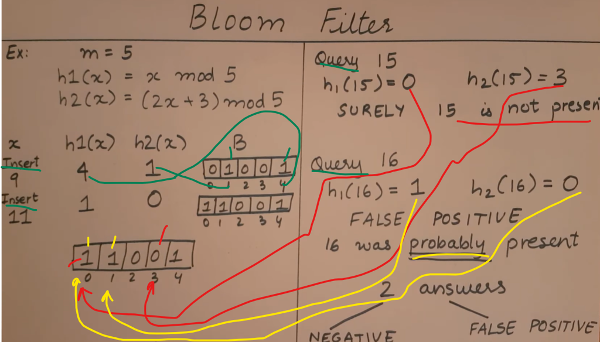

⬆ Back to Index

# 42. Bloom Filter: Use Cases and Pitfalls

Use Bloom Filter when:

- You need membership checks (insta id)
- You are memory constrained
- False positives are acceptable

Good use cases:

- Web crawler visited URL check
- Avoid checking cache when key is definitely absent
- Deduplication with tolerance for false positives
- Database/storage engine existence checks

Pitfalls:

- Standard Bloom filters do not support deletion
- False positives must be acceptable
- Needs proper sizing
- Not useful if exact membership is required
- Can become saturated over time

Interview line:

```
Bloom filter is useful when I need space-efficient membership checks and can tolerate false positives.
```

⬆ Back to Index

# 43. Count-Min Sketch

**Count-Min Sketch** estimates how many times an item appeared in a stream.

It is useful for approximate frequency counting.

It answers:

```
Approximately how many times did user see each add (may be 20 t adds 10 m users)? Store 20 trillion counters in 16KB with Count Min Sketch
```

Properties:

- Uses bounded memory
- Gives approximate counts
- Count is usually an upper bound
- Good for huge streams

Use when exact per-key counters are too expensive.

⬆ Back to Index

# 44. Count-Min Sketch: How It Works

Basic idea:

```
2D array of counters + multiple hash functions
```

Insert/increment:

1. Hash item using multiple hash functions
2. Increment one counter per row

Query:

1. Hash item using same hash functions
2. Read corresponding counters
3. Return the minimum counter

Why minimum?

```
Collisions only increase counts.
Taking the minimum reduces overestimation.
```

Width controls collision probability. Depth controls confidence.

⬆ Back to Index

# 45. Count-Min Sketch: Use Cases and Pitfalls

Use Count-Min Sketch when:

- You need approximate counts
- Data stream is huge
- Memory is limited
- Approximation is acceptable

Good use cases:

- Top K videos/views
- Popular cache keys
- LFU-like cache analysis
- Count page views/events
- Detect heavy hitters

Pitfalls:

- Does not tell you which items exist by itself
- Counts are approximate
- Can overestimate due to collisions
- Not good when exact counts are required
- Still needs non-trivial memory

Interview line:

```
Count-Min Sketch helps estimate frequencies in huge streams using bounded memory.
```

[figure not shown]

[figure not shown]

⬆ Back to Index

# 46. HyperLogLog

**HyperLogLog (HLL)** estimates the number of unique items in a dataset.

This is called cardinality estimation.

It answers:

```
How many distinct users/items/IPs did we see?
```

Instead of storing every unique item in a hash set, HLL uses a compact probabilistic representation.

Good for:

- Billions of unique users/events
- Limited memory
- Approximate unique counts

⬆ Back to Index

# 47. HyperLogLog: How It Works

Basic intuition:

```
Rare hash patterns imply many unique items.
```

How it works:

1. Hash each item
2. Use part of hash to choose a bucket/register
3. Use remaining bits to count leading zeros
4. Track max leading-zero count per bucket
5. Combine buckets to estimate cardinality

More buckets:

```
More memory
Better accuracy
```

HLL gives very memory-efficient approximate unique counts.

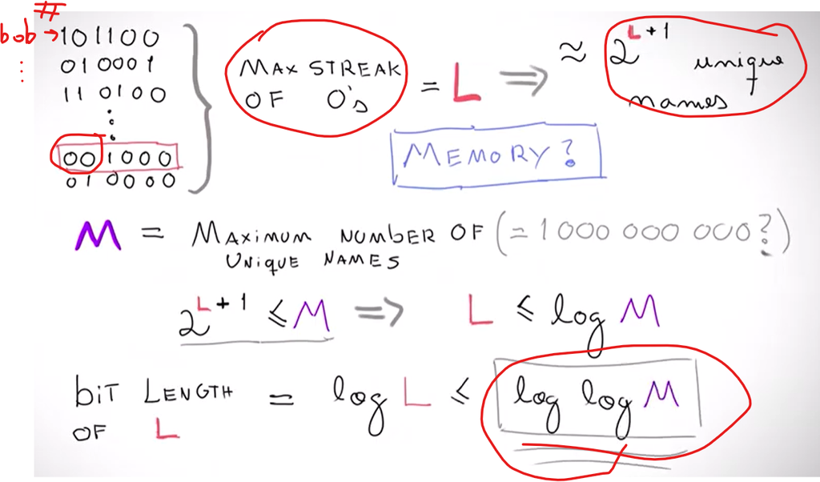

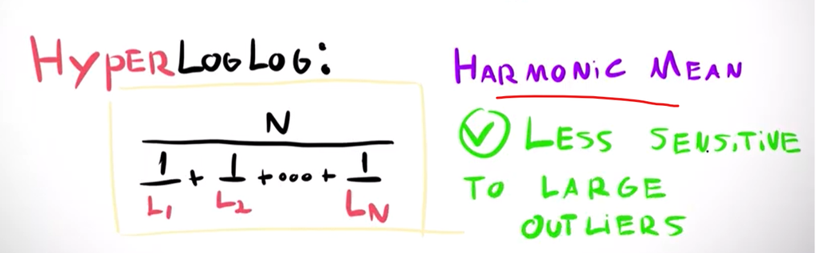

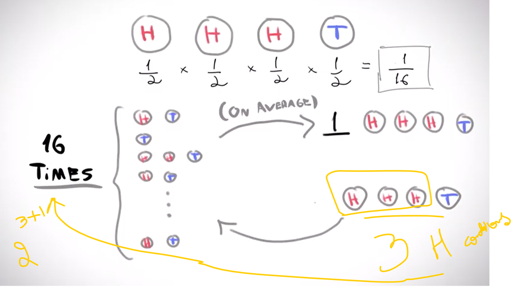

⬆ Back to Index

# 48. HyperLogLog: Use Cases and Pitfalls

Use HyperLogLog when:

- You need distinct counts
- Dataset is huge
- Exact result is not required
- Memory must stay small

Good use cases:

- Daily active users
- Monthly active users
- Unique visitors per page
- Unique IPs
- Distinct search terms
- Cache working-set size
- Anti-scraping signals

Pitfalls:

- Not exact
- Not useful for small cardinalities
- Cannot list the unique items
- Do not use when exact counts are required

Interview line:

```
HLL is great for estimating unique counts at massive scale.
```

⬆ Back to Index

# 49. Approximate Quantiles / Bucket Algorithms

Approximate quantiles help answer:

```
What is p95 latency?
What is p99 response time?
What is median session duration?
```

Exact quantiles require storing/sorting all values, which is too expensive at scale.

Bucket/histogram approach:

1. Define value ranges
2. Count how many values fall into each range
3. Estimate percentiles from cumulative counts

Example:

```
0–10ms     → 1,000
10–50ms    → 8,000
50–100ms   → 800
100–500ms  → 180
500ms+     → 20
```

This gives distribution insight without storing every measurement.

⬆ Back to Index

# 50. Bucket Algorithm Variants

Common variants:

## Fixed-Width Buckets

```
0–10
10–20
20–30
```

Good when values are uniformly distributed and range is known.

## Exponential Buckets

```
1–2ms
2–4ms
4–8ms
8–16ms
```

Good for wide ranges and latency metrics.

## Dynamic Histograms

Buckets adjust based on incoming data distribution.

Pros:

- Better accuracy for unknown distributions

Cons:

- More complex
- Rebalancing required

Important:

```
Quantile error is bounded by bucket width.
```

⬆ Back to Index

# 51. Approximate Quantiles: Use Cases and Pitfalls

Use bucket algorithms when:

- Need percentiles/quantiles
- Dataset is huge
- Streaming analysis is needed
- Bounded memory is required
- Approximation is acceptable

Good use cases:

- APM latency metrics
- Infrastructure monitoring
- p95/p99 response time
- SLO compliance
- A/B testing analytics
- Autoscaling decisions

Pitfalls:

- Poor bucket boundaries reduce accuracy
- Extreme percentiles may be inaccurate
- Values outside expected range need handling
- Too-wide buckets lose precision

Interview line:

```
Histograms/buckets let me estimate percentiles with bounded memory.
```

⬆ Back to Index

# 52. Big Data Structures Decision Table

| Problem | Data Structure |
| --- | --- |
| Need membership check | Bloom Filter |
| Need approximate frequency count | Count-Min Sketch |
| Need unique count/cardinality | HyperLogLog |
| Need percentiles/quantiles | Histogram/Bucket Algorithm |
| Need exact membership | Hash Set |
| Need exact counts | Hash Map / Counter |
| Need exact distinct users | Hash Set / DB query |
| Need p99 at huge scale | Histogram / DDSketch-like approach |

Simple rule:

```
Membership? → Bloom Filter
Frequency? → Count-Min Sketch
Distinct count? → HyperLogLog
Percentiles? → Buckets/Histograms
```

Use approximate structures only when exact structures are too expensive.

⬆ Back to Index

# 53. Final Combined Interview Answer

> For high read traffic, I use caching first. I usually choose Redis with cache-aside and TTL, then add CDN for static/global content. I handle stampedes, hot keys, consistency, and cache failures using request coalescing, invalidation, replication, local fallback caches, and circuit breakers.

> If one database cannot handle storage or read/write throughput, I consider sharding. I choose a shard key with high cardinality, even distribution, and alignment with query patterns. Hash-based sharding is a common default, while range and directory sharding are useful for specific cases. I also plan for hot spots, cross-shard queries, cross-shard transactions, and resharding.

> To reduce data movement when nodes are added or removed, I use consistent hashing. Keys and servers are placed on a hash ring, and virtual nodes improve balance. Consistent hashing distributes keys, but hot traffic still needs replication, salting, or caching.

> For massive datasets where exact data structures are too expensive, I use approximate big-data structures: Bloom Filters for membership, Count-Min Sketch for frequency, HyperLogLog for cardinality, and bucket/histogram algorithms for percentiles. I only use these when memory is constrained and approximation is acceptable.

⬆ Back to Index

# 54. Extra Code: Cache-Aside Pseudocode

⬆ Back to Index

```python
def get_user_profile(user_id, cache, db):
    cache_key = f"user:{user_id}:profile"

    cached = cache.get(cache_key)
    if cached:
        return cached

    profile = db.query(
        "SELECT id, name, email FROM users WHERE id = %s",
        [user_id]
    )

    cache.set(cache_key, profile, ttl_seconds=600)
    return profile
```

# 55. Extra Code: Hash-Based Shard Routing Pseudocode

⬆ Back to Index

```python
def get_shard_id(key, number_of_shards):
    return hash(key) % number_of_shards


def route_user_query(user_id, shards):
    shard_id = get_shard_id(user_id, len(shards))
    shard = shards[shard_id]

    return shard.query(
        "SELECT * FROM users WHERE id = %s",
        [user_id]
    )
```

# 56. Extra Code: Simple Consistent Hash Ring Pseudocode

⬆ Back to Index

```python
import bisect
import hashlib

class ConsistentHashRing:
    def __init__(self, virtual_nodes=3):
        self.virtual_nodes = virtual_nodes
        self.ring = []
        self.node_map = {}

    def _hash(self, key):
        return int(hashlib.md5(key.encode()).hexdigest(), 16)

    def add_node(self, node):
        for i in range(self.virtual_nodes):
            virtual_key = f"{node}-vn{i}"
            position = self._hash(virtual_key)

            bisect.insort(self.ring, position)
            self.node_map[position] = node

    def remove_node(self, node):
        for i in range(self.virtual_nodes):
            virtual_key = f"{node}-vn{i}"
            position = self._hash(virtual_key)

            index = bisect.bisect_left(self.ring, position)
            if index < len(self.ring) and self.ring[index] == position:
                self.ring.pop(index)
                del self.node_map[position]

    def get_node(self, key):
        if not self.ring:
            return None

        position = self._hash(key)
        index = bisect.bisect_left(self.ring, position)

        if index == len(self.ring):
            index = 0

        return self.node_map[self.ring[index]]
```

# 57. Extra Code: Simple Bloom Filter Example

This is a simplified educational implementation.

⬆ Back to Index

```python
import hashlib

class SimpleBloomFilter:
    def __init__(self, size=1000, hash_count=3):
        self.size = size
        self.hash_count = hash_count
        self.bits = [0] * size

    def _hashes(self, item):
        item = str(item)
        for i in range(self.hash_count):
            data = f"{item}:{i}".encode()
            digest = hashlib.md5(data).hexdigest()
            yield int(digest, 16) % self.size

    def add(self, item):
        for position in self._hashes(item):
            self.bits[position] = 1

    def might_contain(self, item):
        return all(self.bits[position] == 1 for position in self._hashes(item))


bf = SimpleBloomFilter(size=100, hash_count=3)
bf.add("url-1")

print(bf.might_contain("url-1"))  # probably true
print(bf.might_contain("url-2"))  # definitely false if any bit is missing
```